# Assignment 5

## Packages

```r
library(forcats)
library(caret)
library(dplyr)
library(ggplot2)
library(tensorflow)
library(keras)
library(reticulate)
library(tfruns)
#install_keras(method="conda", envname="r", tensorflow="gpu")
```

## Section 1 - Data Cleaning

### Q1

- categorical - 47
- numeric - 33 (including SalePrice)
- 1 id field

```r
housing = read.csv("data/housing.csv", stringsAsFactors=TRUE)
summary(housing)
```

[output not shown]

### Q2

- LotFrontage, Alley, MasVnrType, MasVnrArea, BsmtQual, BsmtCond, BsmtExposure, BsmtFinType1, BsmtFinType2, Electrical, FireplaceQu, GarageType, GarageYrBlt, GarageFinish, GarageQual, GarageCond, PoolQC, Fence, MiscFeature
- Percents below
- Note: Some columns NA means none of that feature instead of NA

```r
colMeans(is.na(housing))
```

```
           Id    MSSubClass      MSZoning   LotFrontage       LotArea        Street         Alley      LotShape   LandContour     Utilities     LotConfig     LandSlope  Neighborhood
 0.0000000000  0.0000000000  0.0000000000  0.1773972603  0.0000000000  0.0000000000  0.9376712329  0.0000000000  0.0000000000  0.0000000000  0.0000000000  0.0000000000  0.0000000000
   Condition1    Condition2      BldgType    HouseStyle   OverallQual   OverallCond     YearBuilt  YearRemodAdd     RoofStyle      RoofMatl   Exterior1st   Exterior2nd    MasVnrType
 0.0000000000  0.0000000000  0.0000000000  0.0000000000  0.0000000000  0.0000000000  0.0000000000  0.0000000000  0.0000000000  0.0000000000  0.0000000000  0.0000000000  0.0054794521
   MasVnrArea     ExterQual     ExterCond    Foundation      BsmtQual      BsmtCond  BsmtExposure  BsmtFinType1    BsmtFinSF1  BsmtFinType2    BsmtFinSF2     BsmtUnfSF   TotalBsmtSF
 0.0054794521  0.0000000000  0.0000000000  0.0000000000  0.0253424658  0.0253424658  0.0260273973  0.0253424658  0.0000000000  0.0260273973  0.0000000000  0.0000000000  0.0000000000
      Heating     HeatingQC    CentralAir    Electrical     X1stFlrSF     X2ndFlrSF  LowQualFinSF     GrLivArea  BsmtFullBath  BsmtHalfBath      FullBath      HalfBath  BedroomAbvGr
 0.0000000000  0.0000000000  0.0000000000  0.0006849315  0.0000000000  0.0000000000  0.0000000000  0.0000000000  0.0000000000  0.0000000000  0.0000000000  0.0000000000  0.0000000000
 KitchenAbvGr   KitchenQual  TotRmsAbvGrd    Functional    Fireplaces   FireplaceQu    GarageType   GarageYrBlt  GarageFinish    GarageCars    GarageArea    GarageQual    GarageCond
 0.0000000000  0.0000000000  0.0000000000  0.0000000000  0.0000000000  0.4726027397  0.0554794521  0.0554794521  0.0554794521  0.0000000000  0.0000000000  0.0554794521  0.0554794521
   PavedDrive    WoodDeckSF   OpenPorchSF EnclosedPorch    X3SsnPorch   ScreenPorch      PoolArea        PoolQC         Fence   MiscFeature       MiscVal        MoSold        YrSold
 0.0000000000  0.0000000000  0.0000000000  0.0000000000  0.0000000000  0.0000000000  0.0000000000  0.9952054795  0.8075342466  0.9630136986  0.0000000000  0.0000000000  0.0000000000
     SaleType SaleCondition     SalePrice
 0.0000000000  0.0000000000  0.0000000000
```

### Q3

Remove outliers

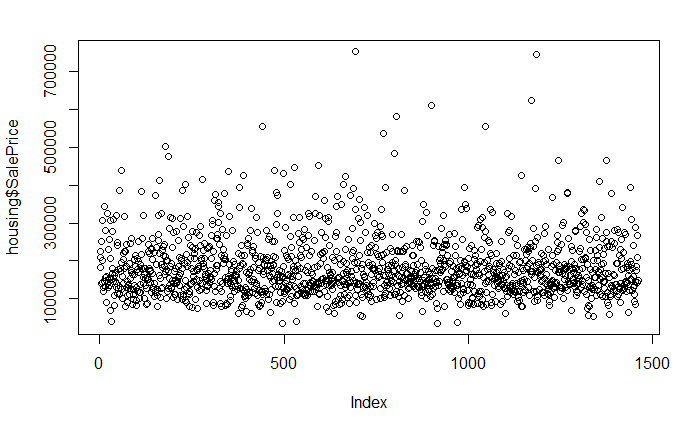

```r
options(scipen=999)
plot(housing$SalePrice)
```

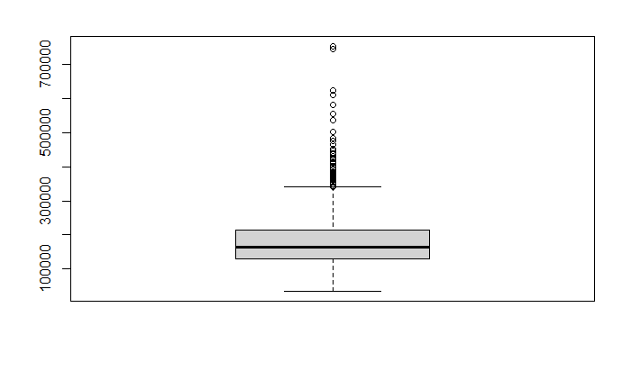

```r
boxplot(housing$SalePrice)
```

```r
housing = housing[housing$SalePrice < 700000,]
```

### Q4-Q5

High percent NA - LotFrontage (18%) Low percent NA - MasVnrType (<1%), MasVnrArea (<1%), Electrical (<1%)

```r
housing$Alley = fct_explicit_na(housing$Alley, na_level="notApp")
housing$BsmtQual = fct_explicit_na(housing$BsmtQual, na_level="notApp")
housing$BsmtCond = fct_explicit_na(housing$BsmtCond, na_level="notApp")
housing$BsmtExposure = fct_explicit_na(housing$BsmtExposure, na_level="notApp")
housing$BsmtFinType1 = fct_explicit_na(housing$BsmtFinType1, na_level="notApp")
housing$BsmtFinType2 = fct_explicit_na(housing$BsmtFinType2, na_level="notApp")
housing$FireplaceQu = fct_explicit_na(housing$FireplaceQu, na_level="notApp")
housing$GarageType = fct_explicit_na(housing$GarageType, na_level="notApp")
housing$GarageYrBlt[is.na(housing$GarageYrBlt)] = 0
housing$GarageFinish = fct_explicit_na(housing$GarageFinish, na_level="notApp")
housing$GarageQual = fct_explicit_na(housing$GarageQual, na_level="notApp")
housing$GarageCond = fct_explicit_na(housing$GarageCond, na_level="notApp")
housing$PoolQC = fct_explicit_na(housing$PoolQC, na_level="notApp")
housing$Fence = fct_explicit_na(housing$Fence, na_level="notApp")
housing$MiscFeature = fct_explicit_na(housing$MiscFeature, na_level="notApp")
# COlumns to factor
housing$MSSubClass = as.factor(housing$MSSubClass)
housing$OverallCond = as.factor(housing$OverallCond)
housing$OverallQual = as.factor(housing$OverallQual)
# Fitler difficult records/columns
housing$Id = NULL
housing = housing[!is.na(housing$MasVnrArea),]
colMeans(is.na(housing))
```

```
   MSSubClass      MSZoning   LotFrontage       LotArea        Street         Alley      LotShape   LandContour     Utilities     LotConfig     LandSlope  Neighborhood    Condition1
 0.0000000000  0.0000000000  0.1772413793  0.0000000000  0.0000000000  0.0000000000  0.0000000000  0.0000000000  0.0000000000  0.0000000000  0.0000000000  0.0000000000  0.0000000000
   Condition2      BldgType    HouseStyle   OverallQual   OverallCond     YearBuilt  YearRemodAdd     RoofStyle      RoofMatl   Exterior1st   Exterior2nd    MasVnrType    MasVnrArea
 0.0000000000  0.0000000000  0.0000000000  0.0000000000  0.0000000000  0.0000000000  0.0000000000  0.0000000000  0.0000000000  0.0000000000  0.0000000000  0.0000000000  0.0000000000
    ExterQual     ExterCond    Foundation      BsmtQual      BsmtCond  BsmtExposure  BsmtFinType1    BsmtFinSF1  BsmtFinType2    BsmtFinSF2     BsmtUnfSF   TotalBsmtSF       Heating
 0.0000000000  0.0000000000  0.0000000000  0.0000000000  0.0000000000  0.0000000000  0.0000000000  0.0000000000  0.0000000000  0.0000000000  0.0000000000  0.0000000000  0.0000000000
    HeatingQC    CentralAir    Electrical     X1stFlrSF     X2ndFlrSF  LowQualFinSF     GrLivArea  BsmtFullBath  BsmtHalfBath      FullBath      HalfBath  BedroomAbvGr  KitchenAbvGr
 0.0000000000  0.0000000000  0.0006896552  0.0000000000  0.0000000000  0.0000000000  0.0000000000  0.0000000000  0.0000000000  0.0000000000  0.0000000000  0.0000000000  0.0000000000
  KitchenQual  TotRmsAbvGrd    Functional    Fireplaces   FireplaceQu    GarageType   GarageYrBlt  GarageFinish    GarageCars    GarageArea    GarageQual    GarageCond    PavedDrive
 0.0000000000  0.0000000000  0.0000000000  0.0000000000  0.0000000000  0.0000000000  0.0000000000  0.0000000000  0.0000000000  0.0000000000  0.0000000000  0.0000000000  0.0000000000
   WoodDeckSF   OpenPorchSF EnclosedPorch    X3SsnPorch   ScreenPorch      PoolArea        PoolQC         Fence   MiscFeature       MiscVal        MoSold        YrSold      SaleType
 0.0000000000  0.0000000000  0.0000000000  0.0000000000  0.0000000000  0.0000000000  0.0000000000  0.0000000000  0.0000000000  0.0000000000  0.0000000000  0.0000000000  0.0000000000
SaleCondition     SalePrice
 0.0000000000  0.0000000000
```

### Q6

```r
mean(complete.cases(housing))
```

```
[1] 0.822069
```

## Section 2 - Data Exploration

### Q8

The skew of SalePrice is right skewed. After log transforming the SalePrice column the histogram is now approximately normal.

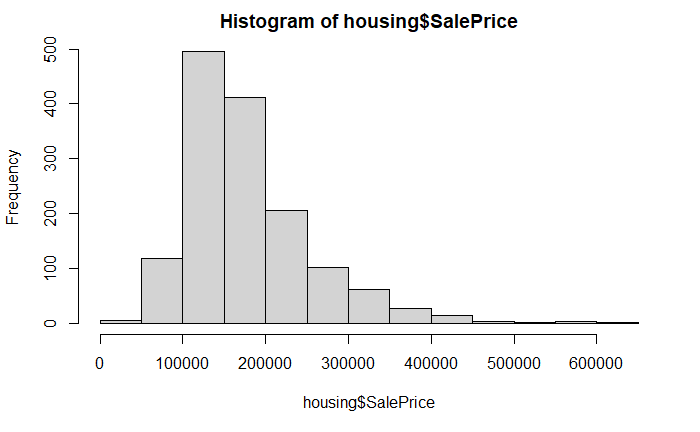

```r
hist(housing$SalePrice)
```

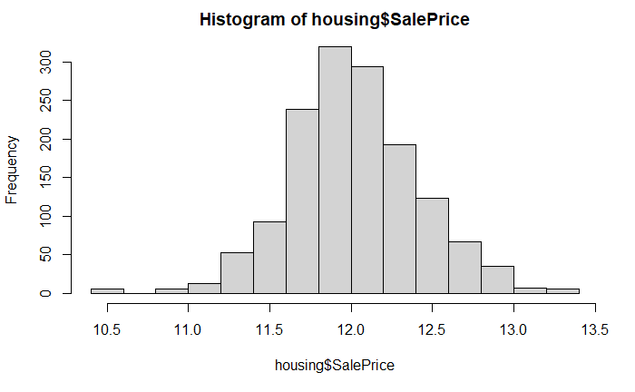

```r
housing$SalePrice = log(housing$SalePrice)
hist(housing$SalePrice)
```

### Q9

- Possible Correlation: MSZoning, Lot Frontage, Alley, LotShape, LandContour, Utilities, Neighborhood, Condition1, Condition2, BldgType, HouseStyle, OverallQual, RoofStyle, RoofMatl, Exterior1st, Exterior2nd, MasVnrType, ExterQual, ExterCond, Foundation, BsmtQual, BsmtCond, BsmtExposure, BsmtFinType1, BsmtFinType2, TotalBsmtSF, Heating, HeatingQC, CentralAir, Electrical, X1stFlrSf, GrLivArea, FullBath, KitchenQual, TotRmsAbvGrd, Functional, Fireplaces, FireplaceQu, GarageType, GarageFinish, GarageCars, GarageArea, GarageQual, GarageCond, PavedDrive, PoolQC, MiscFeature,SaleType, SaleCondition, YearBuilt, YearRemodAdd
- Other columns have very low correlation or plot is difficult to determine

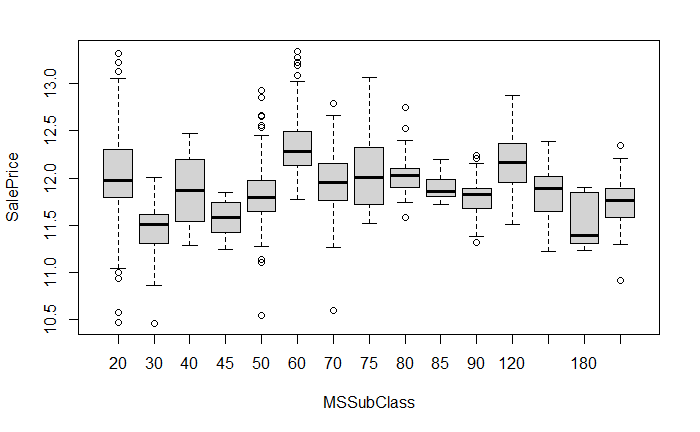

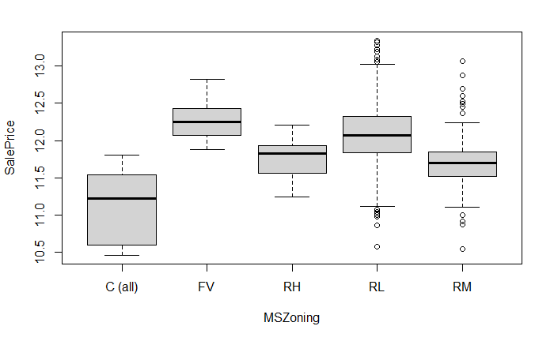

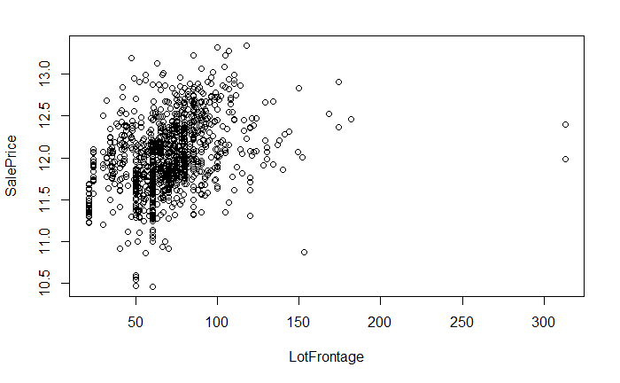

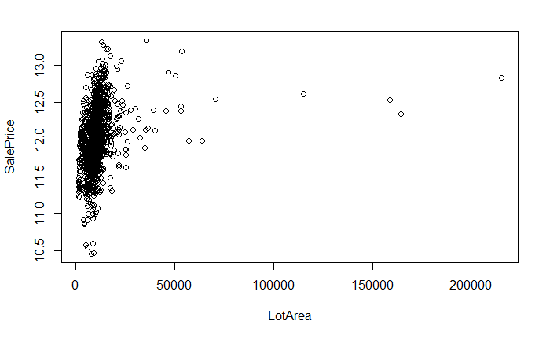

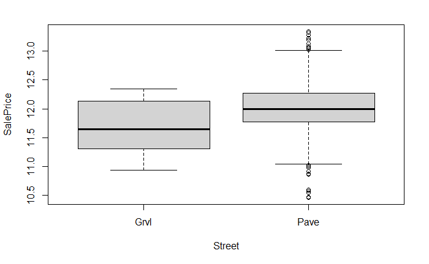

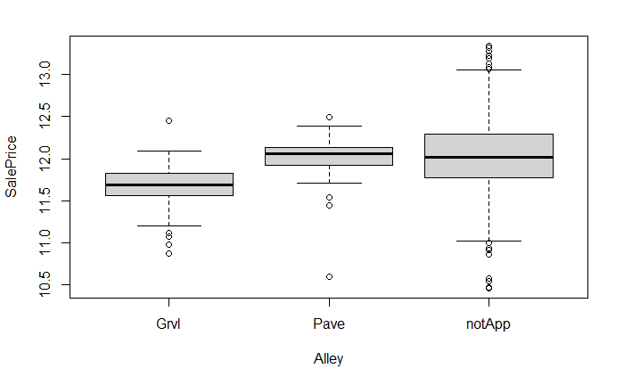

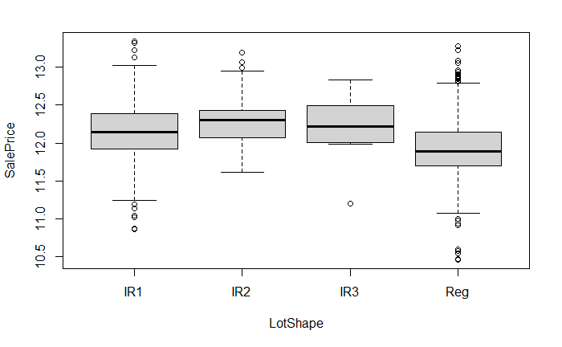

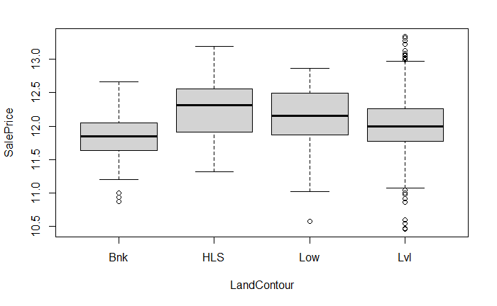

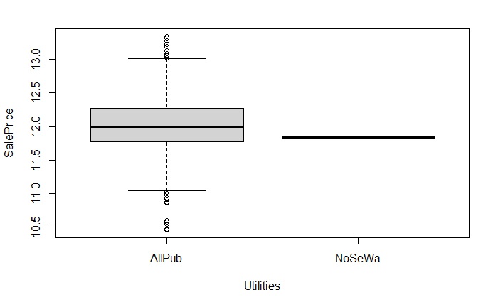

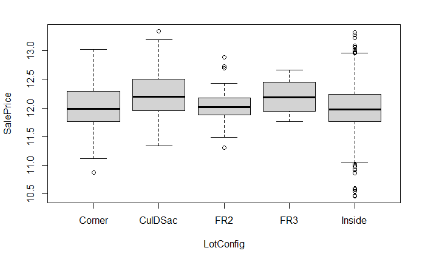

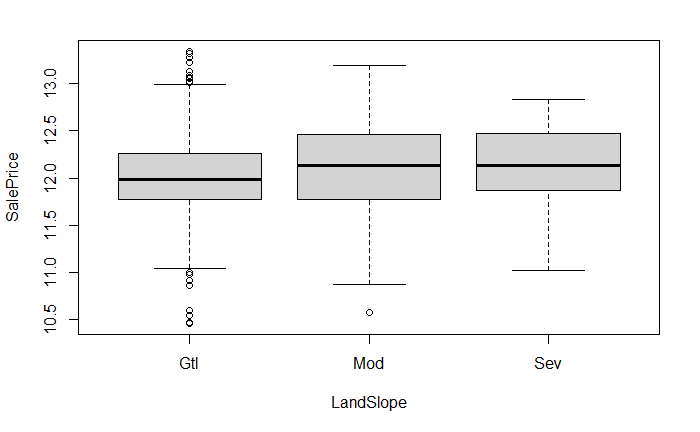

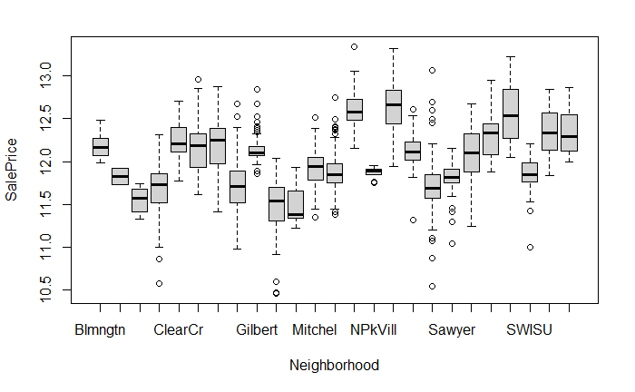

[67 more figures not shown]

```r
library(ggplot2)
library(reshape2)
plot(SalePrice~., data=housing)
```

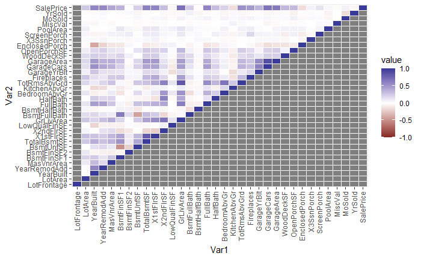

```r
# Some Int variables should be ignored because they are not numeric by definition
get_upper_matrix = function(matrix){
    matrix[lower.tri(matrix)] = NA
    return(matrix)
  }
corr_mat = melt(get_upper_matrix(cor(housing[sapply(housing,is.numeric)])))
ggplot(data = corr_mat, aes(x=Var1, y=Var2, fill=value)) +
  geom_tile(color="white") +
  scale_fill_gradient2(midpoint=0,limit=c(-1,1)) +
  theme(axis.text.x=element_text(angle=90, vjust=.4, hjust=1))
```

## Train and Test Sets

### Q10 - Missing Values

Categoric - MasVnrType (<1%), Electrical (<1%) Numeric - LotFrontage (18%), MasVnrArea (<1%)

```r
set.seed(1)
train_index = createDataPartition(housing$SalePrice, p=0.8, list=FALSE)
housing_train = housing[train_index,]
housing_test = housing[-train_index,]
t = table(housing_train$MasVnrType)
housing_train$MasVnrType = fct_explicit_na(housing_train$MasVnrType, na_level=names(t[t == max(t)]))
housing_test$MasVnrType = fct_explicit_na(housing_test$MasVnrType, na_level=names(t[t == max(t)]))
t = table(housing_train$Electrical)
housing_train$Electrical = fct_explicit_na(housing_train$Electrical, na_level=names(t[t == max(t)]))
housing_test$Electrical = fct_explicit_na(housing_test$Electrical, na_level=names(t[t == max(t)]))
#dummy = dummyVars(" ~ .", data=housing)
#housing_train = data.frame(predict(dummy, newdata=housing_train))
#housing_test = data.frame(predict(dummy, newdata=housing_test))
# Verify categoric nulls removed
colMeans(is.na(housing_train))
```

```
   MSSubClass      MSZoning   LotFrontage       LotArea        Street         Alley      LotShape   LandContour     Utilities     LotConfig     LandSlope  Neighborhood    Condition1
    0.0000000     0.0000000     0.1782946     0.0000000     0.0000000     0.0000000     0.0000000     0.0000000     0.0000000     0.0000000     0.0000000     0.0000000     0.0000000
   Condition2      BldgType    HouseStyle   OverallQual   OverallCond     YearBuilt  YearRemodAdd     RoofStyle      RoofMatl   Exterior1st   Exterior2nd    MasVnrType    MasVnrArea
    0.0000000     0.0000000     0.0000000     0.0000000     0.0000000     0.0000000     0.0000000     0.0000000     0.0000000     0.0000000     0.0000000     0.0000000     0.0000000
    ExterQual     ExterCond    Foundation      BsmtQual      BsmtCond  BsmtExposure  BsmtFinType1    BsmtFinSF1  BsmtFinType2    BsmtFinSF2     BsmtUnfSF   TotalBsmtSF       Heating
    0.0000000     0.0000000     0.0000000     0.0000000     0.0000000     0.0000000     0.0000000     0.0000000     0.0000000     0.0000000     0.0000000     0.0000000     0.0000000
    HeatingQC    CentralAir    Electrical     X1stFlrSF     X2ndFlrSF  LowQualFinSF     GrLivArea  BsmtFullBath  BsmtHalfBath      FullBath      HalfBath  BedroomAbvGr  KitchenAbvGr
    0.0000000     0.0000000     0.0000000     0.0000000     0.0000000     0.0000000     0.0000000     0.0000000     0.0000000     0.0000000     0.0000000     0.0000000     0.0000000
  KitchenQual  TotRmsAbvGrd    Functional    Fireplaces   FireplaceQu    GarageType   GarageYrBlt  GarageFinish    GarageCars    GarageArea    GarageQual    GarageCond    PavedDrive
    0.0000000     0.0000000     0.0000000     0.0000000     0.0000000     0.0000000     0.0000000     0.0000000     0.0000000     0.0000000     0.0000000     0.0000000     0.0000000
   WoodDeckSF   OpenPorchSF EnclosedPorch    X3SsnPorch   ScreenPorch      PoolArea        PoolQC         Fence   MiscFeature       MiscVal        MoSold        YrSold      SaleType
    0.0000000     0.0000000     0.0000000     0.0000000     0.0000000     0.0000000     0.0000000     0.0000000     0.0000000     0.0000000     0.0000000     0.0000000     0.0000000
SaleCondition     SalePrice
    0.0000000     0.0000000
```

## Section 3.1 - Create Predictive Models

### Q11 - Lasso

Lasso shrunk many coefficients to zero. These variables are considered irrelevant to the lasso algorithm.

```r
library(RANN)
set.seed(1)
lasso = train(SalePrice~., data=housing_train,
              method="glmnet",
              preProcess=c("knnImpute","nzv"),
              na.action=na.pass,
              trControl=trainControl("cv", number=10),
              tuneGrid=expand.grid(alpha=1, lambda=seq(0,.2,length=100)))
lasso_predict = predict(lasso, housing_test, na.action=na.pass)
RMSE(lasso_predict, housing_test$SalePrice)
```

```
[1] 0.1450089
```

```r
coef(lasso$finalModel, lasso$BestTune$lambda)
```

```
118 x 100 sparse Matrix of class "dgCMatrix"
```

[output not shown]

[output not shown]

[output cut: 15 more lines]

[output not shown]

[output not shown]

### Q12 - Ridge

```r
set.seed(1)
ridge = train(SalePrice~., data=housing_train,
              method="glmnet",
              preProcess=c("knnImpute","nzv"),
              na.action=na.pass,
              trControl=trainControl("cv", number=10),
              tuneGrid=expand.grid(alpha=0, lambda=seq(0,.2, length=100)))
ridge_predict = predict(ridge, housing_test, na.action=na.pass)
RMSE(ridge_predict, housing_test$SalePrice)
```

```
[1] 0.151161
```

### Q13 - Elastic net

```r
set.seed(1)
enet = train(SalePrice~., data=housing_train,
              method="glmnet",
              preProcess=c("knnImpute","nzv"),
              na.action=na.pass,
              trControl=trainControl("cv", number=10),
              tuneGrid=expand.grid(alpha=seq(0,1, length=10), lambda=seq(0,.2, length=100)))
enet_predict = predict(enet, housing_test, na.action=na.pass)
RMSE(enet_predict, housing_test$SalePrice)
```

```
[1] 0.151161
```

## Section 3.2 - Tree-Ensemble Model

### Q14 - Random Forest

```r
set.seed(1)
rfm = train(SalePrice~., data=housing_train,
            method="rf",
            preProcess="knnImpute",
            na.action=na.pass,
            trControl=trainControl("cv", number=10),
            tuneGrid=expand.grid(mtry= c(2, 4, 8, 16)),
            importance=T)
```

[output not shown]

```r
rfm_predict = predict(rfm, housing_test, na.action=na.pass)
RMSE(rfm_predict, housing_test$SalePrice)
```

```
[1] 0.1597264
```

```r
varImp(rfm)
```

```
rf variable importance

  only 20 most important variables shown (out of 287)
```

|  | Overall |
| --- | --- |
| GrLivArea | 100.00000 |
| X2ndFlrSF | 80.39371 |
| TotalBsmtSF | 79.68167 |
| LotArea | 74.38508 |
| X1stFlrSF | 74.05002 |
| BsmtFinSF1 | 72.76767 |
| GarageArea | 72.25213 |
| LotFrontage | 68.39035 |
| Fireplaces | 67.60869 |
| YearBuilt | 65.26549 |

[output cut: 10 more lines]

### Q15 - Gradient Boosted Tree

```r
set.seed(1)
gbm = train(SalePrice~., data=housing_train,
            method="gbm",
            na.action=na.pass,
            trControl=trainControl("cv", number=10))
```

[output not shown]

[output not shown]

[output not shown]

[output not shown]

[output not shown]

[output not shown]

[output not shown]

[output not shown]

[output not shown]

[output not shown]

[output not shown]

[output not shown]

[output not shown]

[output not shown]

[output not shown]

[output not shown]

[output not shown]

[output not shown]

[output not shown]

[output not shown]

[output not shown]

[output not shown]

[output not shown]

[output not shown]

[output not shown]

[output not shown]

[output not shown]

[output not shown]

[output not shown]

[output not shown]

[output not shown]

```r
gbm_predict = predict(gbm, housing_test, na.action=na.pass)
RMSE(gbm_predict, housing_test$SalePrice)
```

```
[1] 0.1402569
```

### Q16 - Resamples

Old: According to the plots and values below, the Elastic Net or Lasso models are likely the best performing model. Their values match for performance. They have the lowest MAE, highest R^2, and their RMSE is very low. Updated: After removing dummy the models produced different results. Now appears GBM may be best model with highest R^2 and lowest overall MAE/RMSE.

```r
results = resamples(list(L=lasso,Rdg=ridge,E=enet,RF=rfm,GBM=gbm))
summary(results)
```

```
Call:
summary.resamples(object = results)

Models: L, Rdg, E, RF, GBM
Number of resamples: 10

MAE
          Min.    1st Qu.    Median       Mean   3rd Qu.      Max. NA's
L   0.09023666 0.09682084 0.1051255 0.10600239 0.1137739 0.1293388    0
Rdg 0.08714463 0.09681092 0.1049926 0.10544386 0.1151455 0.1265497    0
E   0.08714463 0.09681092 0.1049926 0.10544386 0.1151455 0.1265497    0
RF  0.07891041 0.09546865 0.1027718 0.10025425 0.1051941 0.1120030    0
GBM 0.07746118 0.08720064 0.0922500 0.09315747 0.1010580 0.1049199    0

RMSE
         Min.   1st Qu.    Median      Mean   3rd Qu.      Max. NA's
L   0.1170513 0.1326272 0.1454800 0.1632406 0.1606967 0.3503292    0
Rdg 0.1204547 0.1276680 0.1503798 0.1594709 0.1614356 0.3051537    0
E   0.1204547 0.1276680 0.1503798 0.1594709 0.1614356 0.3051537    0
RF  0.1189722 0.1365779 0.1488805 0.1498102 0.1677651 0.1788030    0
GBM 0.1057427 0.1241815 0.1309465 0.1365414 0.1415028 0.1953440    0

Rsquared
         Min.   1st Qu.    Median      Mean   3rd Qu.      Max. NA's
L   0.5432340 0.8400372 0.8712063 0.8383446 0.8843016 0.9098769    0
Rdg 0.5876961 0.8448517 0.8739553 0.8438071 0.8859310 0.9093760    0
E   0.5876961 0.8448517 0.8739553 0.8438071 0.8859310 0.9093760    0
RF  0.7937955 0.8460949 0.8785537 0.8683136 0.8916190 0.9226433    0
GBM 0.7872438 0.8773799 0.8855679 0.8805729 0.9024144 0.9278467    0
```

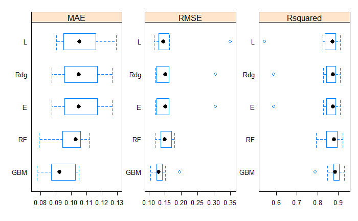

```r
bwplot(results, scales=list(relation="free"))
```

## Section 3.3 Neural Network

### Packages

```r
library(tensorflow)
library(keras)
library(reticulate)
library(tfruns)
install_keras(method="conda", envname="r", tensorflow="gpu")
```

[output not shown]

### Q17 - Split Training and Validation

```r
set.seed(1)
test_index = createDataPartition(housing$SalePrice, p=0.2, list=FALSE)
housing_train_n_labels = housing[-test_index,80]
housing_train_n = housing[-test_index,-80]
housing_test_n_labels = housing[test_index,80]
housing_test_n = housing[test_index,-80]
val_index = createDataPartition(housing_train_n_labels, p=0.1, list=FALSE)
housing_val_labels = housing_train_n_labels[val_index]
housing_val_n = housing_train_n[val_index,-80]
housing_vtrain_labels = housing_train_n_labels[-val_index]
housing_vtrain_n = housing_train_n[-val_index,-80]
t = table(housing_vtrain_n$MasVnrType)
housing_train_n$MasVnrType = fct_explicit_na(housing_train_n$MasVnrType, na_level=names(t[t == max(t)]))
housing_test_n$MasVnrType = fct_explicit_na(housing_test_n$MasVnrType, na_level=names(t[t == max(t)]))
housing_val_n$MasVnrType = fct_explicit_na(housing_val_n$MasVnrType, na_level=names(t[t == max(t)]))
housing_vtrain_n$MasVnrType = fct_explicit_na(housing_vtrain_n$MasVnrType, na_level=names(t[t == max(t)]))
t = table(housing_vtrain_n$Electrical)
housing_train_n$Electrical = fct_explicit_na(housing_train_n$Electrical, na_level=names(t[t == max(t)]))
housing_test_n$Electrical = fct_explicit_na(housing_test_n$Electrical, na_level=names(t[t == max(t)]))
housing_val_n$Electrical = fct_explicit_na(housing_val_n$Electrical, na_level=names(t[t == max(t)]))
housing_vtrain_n$Electrical = fct_explicit_na(housing_vtrain_n$Electrical, na_level=names(t[t == max(t)]))
```

### Q18 - Imputation

```r
preproc = preProcess(housing_vtrain_n, method="knnImpute")
train_impute = predict(preproc, housing_train_n)
vtrain_imput = predict(preproc, housing_vtrain_n)
test_impute = predict(preproc, housing_test_n)
val_impute = predict(preproc, housing_val_n)
```

### Q19 - One-hot Encoding

```r
set.seed(1)
dummy = dummyVars(" ~ .", data=housing[,-80])
housing_train_n = data.matrix(predict(dummy, newdata=train_impute))
housing_vtrain_n = data.matrix(predict(dummy, newdata=vtrain_imput))
housing_test_n = data.matrix(predict(dummy, newdata=test_impute))
housing_val_n = data.matrix(predict(dummy, newdata=val_impute))
```

### Q20 - Neural Network

- 2 hidden layers

#### Tuning Run

```r
set.seed(1)
runs <- tuning_run("house_tuning.R",
                   flags = list(nodes=c(64, 128, 392),
                                learning_rate=c(0.01, 0.05, 0.001, 0.0001),
                                batch_size=c(100,200,500,1000),
                                epochs=c(30,50,100),
                                activation=c("relu","sigmoid","tanh"),
                                dropout1=.5,
                                dropout2=.5),
                   sample = 0.02 # Take a 2% sample of the entire 432 combinations
                   )
```

```
432 total combinations of flags
(sampled to 9 combinations)
```

```r
y
```

```
Training run 1/9 (flags = list(392, 0.0001, 500, 30, "tanh", 0.5, 0.5))
Using run directory runs/2021-04-18T16-58-45Z
```

```
> # Parameters for dataset
> FLAGS <-flags(flag_numeric("nodes", 128),
+               flag_numeric("batch_size", 100),
+               flag_string("a ..." ... [TRUNCATED]

> # Model
> model = keras_model_sequential() %>%
+   layer_dense(units=FLAGS$nodes,
+               activation=FLAGS$activation,
+               inpu .... [TRUNCATED]
```

[output not shown]

```
> # Compile Model
> ## Could use metrics='acc' on other models but did not here
> model %>% compile(loss="mse",
+                   optimizer=optimize .... [TRUNCATED]

> # Train Model
> history <- model %>% fit(housing_vtrain_n,
+                          housing_vtrain_labels,
+                          batch_size .... [TRUNCATED]
```

```
2021-04-18 12:59:00.092822: I tensorflow/compiler/mlir/mlir_graph_optimization_pass.cc:116] None of the MLIR optimization passes are enabled (registered 2)
```

```
WARNING:tensorflow:Callback method `on_train_batch_end` is slow compared to the batch time (batch time: 0.0054s vs `on_train_batch_end` time: 0.0293s). Check your callbacks.
```

```
> # Predict
> predict_labels <- model %>% predict(housing_val_n)

> rmse <- function(x,y) {
+   return((mean((x-y)^2))^.5)
+ }

> rmse(predict_labels,housing_val_labels)
[1] 1.527829
```

```
Run completed: runs/2021-04-18T16-58-45Z

Training run 2/9 (flags = list(128, 0.0001, 200, 30, "sigmoid", 0.5, 0.5))
Using run directory runs/2021-04-18T16-59-14Z
```

```
> # Parameters for dataset
> FLAGS <-flags(flag_numeric("nodes", 128),
+               flag_numeric("batch_size", 100),
+               flag_string("a ..." ... [TRUNCATED]

> # Model
> model = keras_model_sequential() %>%
+   layer_dense(units=FLAGS$nodes,
+               activation=FLAGS$activation,
+               inpu .... [TRUNCATED]

> # Compile Model
> ## Could use metrics='acc' on other models but did not here
> model %>% compile(loss="mse",
+                   optimizer=optimize .... [TRUNCATED]

> # Train Model
> history <- model %>% fit(housing_vtrain_n,
+                          housing_vtrain_labels,
+                          batch_size .... [TRUNCATED]
```

```
WARNING:tensorflow:Callback method `on_train_batch_begin` is slow compared to the batch time (batch time: 0.0014s vs `on_train_batch_begin` time: 0.0330s). Check your callbacks.
WARNING:tensorflow:Callback method `on_train_batch_end` is slow compared to the batch time (batch time: 0.0014s vs `on_train_batch_end` time: 0.0021s). Check your callbacks.
```

```
> # Predict
> predict_labels <- model %>% predict(housing_val_n)

> rmse <- function(x,y) {
+   return((mean((x-y)^2))^.5)
+ }

> rmse(predict_labels,housing_val_labels)
[1] 5.543995
```

```
Run completed: runs/2021-04-18T16-59-14Z

Training run 3/9 (flags = list(392, 0.001, 500, 100, "relu", 0.5, 0.5))
Using run directory runs/2021-04-18T16-59-26Z
```

```
> # Parameters for dataset
> FLAGS <-flags(flag_numeric("nodes", 128),
+               flag_numeric("batch_size", 100),
+               flag_string("a ..." ... [TRUNCATED]

> # Model
> model = keras_model_sequential() %>%
+   layer_dense(units=FLAGS$nodes,
+               activation=FLAGS$activation,
+               inpu .... [TRUNCATED]

> # Compile Model
> ## Could use metrics='acc' on other models but did not here
> model %>% compile(loss="mse",
+                   optimizer=optimize .... [TRUNCATED]

> # Train Model
> history <- model %>% fit(housing_vtrain_n,
+                          housing_vtrain_labels,
+                          batch_size .... [TRUNCATED]
```

```
WARNING:tensorflow:Callback method `on_train_batch_begin` is slow compared to the batch time (batch time: 0.0052s vs `on_train_batch_begin` time: 0.0472s). Check your callbacks.
```

```
> # Predict
> predict_labels <- model %>% predict(housing_val_n)

> rmse <- function(x,y) {
+   return((mean((x-y)^2))^.5)
+ }

> rmse(predict_labels,housing_val_labels)
[1] 0.5895226
```

```
Run completed: runs/2021-04-18T16-59-26Z

Training run 4/9 (flags = list(64, 0.0001, 500, 100, "tanh", 0.5, 0.5))
Using run directory runs/2021-04-18T17-00-08Z
```

```
> # Parameters for dataset
> FLAGS <-flags(flag_numeric("nodes", 128),
+               flag_numeric("batch_size", 100),
+               flag_string("a ..." ... [TRUNCATED]

> # Model
> model = keras_model_sequential() %>%
+   layer_dense(units=FLAGS$nodes,
+               activation=FLAGS$activation,
+               inpu .... [TRUNCATED]

> # Compile Model
> ## Could use metrics='acc' on other models but did not here
> model %>% compile(loss="mse",
+                   optimizer=optimize .... [TRUNCATED]

> # Train Model
> history <- model %>% fit(housing_vtrain_n,
+                          housing_vtrain_labels,
+                          batch_size .... [TRUNCATED]
```

```
WARNING:tensorflow:Callback method `on_train_batch_end` is slow compared to the batch time (batch time: 0.0012s vs `on_train_batch_end` time: 0.0014s). Check your callbacks.
```

```
> # Predict
> predict_labels <- model %>% predict(housing_val_n)

> rmse <- function(x,y) {
+   return((mean((x-y)^2))^.5)
+ }

> rmse(predict_labels,housing_val_labels)
[1] 2.830384
```

```
Run completed: runs/2021-04-18T17-00-08Z

Training run 5/9 (flags = list(128, 0.0001, 100, 30, "tanh", 0.5, 0.5))
Using run directory runs/2021-04-18T17-00-44Z
```

```
> # Parameters for dataset
> FLAGS <-flags(flag_numeric("nodes", 128),
+               flag_numeric("batch_size", 100),
+               flag_string("a ..." ... [TRUNCATED]

> # Model
> model = keras_model_sequential() %>%
+   layer_dense(units=FLAGS$nodes,
+               activation=FLAGS$activation,
+               inpu .... [TRUNCATED]

> # Compile Model
> ## Could use metrics='acc' on other models but did not here
> model %>% compile(loss="mse",
+                   optimizer=optimize .... [TRUNCATED]

> # Train Model
> history <- model %>% fit(housing_vtrain_n,
+                          housing_vtrain_labels,
+                          batch_size .... [TRUNCATED]
```

```
WARNING:tensorflow:Callback method `on_train_batch_end` is slow compared to the batch time (batch time: 0.0015s vs `on_train_batch_end` time: 0.0301s). Check your callbacks.
```

```
> # Predict
> predict_labels <- model %>% predict(housing_val_n)

> rmse <- function(x,y) {
+   return((mean((x-y)^2))^.5)
+ }

> rmse(predict_labels,housing_val_labels)
[1] 1.223927
```

```
Run completed: runs/2021-04-18T17-00-44Z

Training run 6/9 (flags = list(392, 0.05, 500, 100, "sigmoid", 0.5, 0.5))
Using run directory runs/2021-04-18T17-00-57Z
```

```
> # Parameters for dataset
> FLAGS <-flags(flag_numeric("nodes", 128),
+               flag_numeric("batch_size", 100),
+               flag_string("a ..." ... [TRUNCATED]

> # Model
> model = keras_model_sequential() %>%
+   layer_dense(units=FLAGS$nodes,
+               activation=FLAGS$activation,
+               inpu .... [TRUNCATED]

> # Compile Model
> ## Could use metrics='acc' on other models but did not here
> model %>% compile(loss="mse",
+                   optimizer=optimize .... [TRUNCATED]

> # Train Model
> history <- model %>% fit(housing_vtrain_n,
+                          housing_vtrain_labels,
+                          batch_size .... [TRUNCATED]
```

```
WARNING:tensorflow:Callback method `on_train_batch_end` is slow compared to the batch time (batch time: 0.0050s vs `on_train_batch_end` time: 0.0089s). Check your callbacks.
```

```
> # Predict
> predict_labels <- model %>% predict(housing_val_n)

> rmse <- function(x,y) {
+   return((mean((x-y)^2))^.5)
+ }

> rmse(predict_labels,housing_val_labels)
[1] 0.4926511
```

```
Run completed: runs/2021-04-18T17-00-57Z

Training run 7/9 (flags = list(64, 0.001, 1000, 30, "sigmoid", 0.5, 0.5))
Using run directory runs/2021-04-18T17-01-36Z
```

```
> # Parameters for dataset
> FLAGS <-flags(flag_numeric("nodes", 128),
+               flag_numeric("batch_size", 100),
+               flag_string("a ..." ... [TRUNCATED]

> # Model
> model = keras_model_sequential() %>%
+   layer_dense(units=FLAGS$nodes,
+               activation=FLAGS$activation,
+               inpu .... [TRUNCATED]

> # Compile Model
> ## Could use metrics='acc' on other models but did not here
> model %>% compile(loss="mse",
+                   optimizer=optimize .... [TRUNCATED]

> # Train Model
> history <- model %>% fit(housing_vtrain_n,
+                          housing_vtrain_labels,
+                          batch_size .... [TRUNCATED]
```

```
WARNING:tensorflow:Callback method `on_train_batch_end` is slow compared to the batch time (batch time: 0.0007s vs `on_train_batch_end` time: 0.0012s). Check your callbacks.
```

```
> # Predict
> predict_labels <- model %>% predict(housing_val_n)

> rmse <- function(x,y) {
+   return((mean((x-y)^2))^.5)
+ }

> rmse(predict_labels,housing_val_labels)
[1] 5.369111
```

```
Run completed: runs/2021-04-18T17-01-36Z

Training run 8/9 (flags = list(64, 0.001, 200, 30, "tanh", 0.5, 0.5))
Using run directory runs/2021-04-18T17-01-50Z
```

```
> # Parameters for dataset
> FLAGS <-flags(flag_numeric("nodes", 128),
+               flag_numeric("batch_size", 100),
+               flag_string("a ..." ... [TRUNCATED]

> # Model
> model = keras_model_sequential() %>%
+   layer_dense(units=FLAGS$nodes,
+               activation=FLAGS$activation,
+               inpu .... [TRUNCATED]

> # Compile Model
> ## Could use metrics='acc' on other models but did not here
> model %>% compile(loss="mse",
+                   optimizer=optimize .... [TRUNCATED]

> # Train Model
> history <- model %>% fit(housing_vtrain_n,
+                          housing_vtrain_labels,
+                          batch_size .... [TRUNCATED]
```

```
WARNING:tensorflow:Callback method `on_train_batch_begin` is slow compared to the batch time (batch time: 0.0014s vs `on_train_batch_begin` time: 0.0306s). Check your callbacks.
WARNING:tensorflow:Callback method `on_train_batch_end` is slow compared to the batch time (batch time: 0.0014s vs `on_train_batch_end` time: 0.0728s). Check your callbacks.
```

```
> # Predict
> predict_labels <- model %>% predict(housing_val_n)

> rmse <- function(x,y) {
+   return((mean((x-y)^2))^.5)
+ }

> rmse(predict_labels,housing_val_labels)
[1] 0.4302391
```

```
Run completed: runs/2021-04-18T17-01-50Z

Training run 9/9 (flags = list(64, 0.01, 1000, 50, "relu", 0.5, 0.5))
Using run directory runs/2021-04-18T17-02-03Z
```

```
> # Parameters for dataset
> FLAGS <-flags(flag_numeric("nodes", 128),
+               flag_numeric("batch_size", 100),
+               flag_string("a ..." ... [TRUNCATED]

> # Model
> model = keras_model_sequential() %>%
+   layer_dense(units=FLAGS$nodes,
+               activation=FLAGS$activation,
+               inpu .... [TRUNCATED]

> # Compile Model
> ## Could use metrics='acc' on other models but did not here
> model %>% compile(loss="mse",
+                   optimizer=optimize .... [TRUNCATED]

> # Train Model
> history <- model %>% fit(housing_vtrain_n,
+                          housing_vtrain_labels,
+                          batch_size .... [TRUNCATED]
```

```
WARNING:tensorflow:Callback method `on_train_batch_end` is slow compared to the batch time (batch time: 0.0008s vs `on_train_batch_end` time: 0.0011s). Check your callbacks.
```

```
> # Predict
> predict_labels <- model %>% predict(housing_val_n)

> rmse <- function(x,y) {
+   return((mean((x-y)^2))^.5)
+ }

> rmse(predict_labels,housing_val_labels)
[1] 1.38944
```

```
Run completed: runs/2021-04-18T17-02-03Z
```

### Q21 - View Runs

Val_loss stays below loss the entire set and bottoms out near epoch 25. The difference in values could indicate possible underfitting. The parameters ended with nodes=64, batch=200, activation=tanh, learn_rate=.001,epochs=30,dropout1/2=.5.

```r
view_run(runs$run_dir[which.min(runs$metric_val_loss)])
```

```
argument 'compressed' is ignored for the internal method
```

### Q22 - Predict SalePrice

```r
set.seed(1)
# Model
model = keras_model_sequential() %>%
  layer_dense(units=64,
              activation='tanh',
              input_shape=dim(housing_train_n)[2]) %>%
  layer_dropout(.5) %>%
  layer_dense(units=64,
              activation='tanh') %>%
  layer_dropout(.5) %>%
  layer_dense(units=1)
# Compile Model
## Could use metrics='acc' on other models but did not here
model %>% compile(loss="mse",
                  optimizer=optimizer_adam(lr=.001)
)
# Train Model
history <- model %>% fit(housing_train_n,
                         housing_train_n_labels,
                         batch_size=200,
                         epochs=30,
                         validation_data=list(housing_test_n, housing_test_n_labels)
)
# Predict
predict_labels <- model %>% predict(housing_test_n)
rmse <- function(x,y) {
  return((mean((x-y)^2))^.5)
}
nn = rmse(predict_labels,housing_test_n_labels)
nn
```

```
[1] 0.4923612
```

### Q23 - Compare Models to Neural Network

Old: The RMSE of the other models indicates better performance than the neural network. The model that performed the best is Elastic Net or Lasso, taking into account R^2. Updated: The model that performed best would be GBM when taking into account MAE/RMSE and R^2.

```r
summary(results)
```

```
Call:
summary.resamples(object = results)

Models: L, Rdg, E, RF, GBM
Number of resamples: 10

MAE
          Min.    1st Qu.    Median       Mean   3rd Qu.      Max. NA's
L   0.09023666 0.09682084 0.1051255 0.10600239 0.1137739 0.1293388    0
Rdg 0.08714463 0.09681092 0.1049926 0.10544386 0.1151455 0.1265497    0
E   0.08714463 0.09681092 0.1049926 0.10544386 0.1151455 0.1265497    0
RF  0.07891041 0.09546865 0.1027718 0.10025425 0.1051941 0.1120030    0
GBM 0.07746118 0.08720064 0.0922500 0.09315747 0.1010580 0.1049199    0

RMSE
         Min.   1st Qu.    Median      Mean   3rd Qu.      Max. NA's
L   0.1170513 0.1326272 0.1454800 0.1632406 0.1606967 0.3503292    0
Rdg 0.1204547 0.1276680 0.1503798 0.1594709 0.1614356 0.3051537    0
E   0.1204547 0.1276680 0.1503798 0.1594709 0.1614356 0.3051537    0
RF  0.1189722 0.1365779 0.1488805 0.1498102 0.1677651 0.1788030    0
GBM 0.1057427 0.1241815 0.1309465 0.1365414 0.1415028 0.1953440    0

Rsquared
         Min.   1st Qu.    Median      Mean   3rd Qu.      Max. NA's
L   0.5432340 0.8400372 0.8712063 0.8383446 0.8843016 0.9098769    0
Rdg 0.5876961 0.8448517 0.8739553 0.8438071 0.8859310 0.9093760    0
E   0.5876961 0.8448517 0.8739553 0.8438071 0.8859310 0.9093760    0
RF  0.7937955 0.8460949 0.8785537 0.8683136 0.8916190 0.9226433    0
GBM 0.7872438 0.8773799 0.8855679 0.8805729 0.9024144 0.9278467    0
```

```r
nn
```

```
[1] 0.4923612
```